# GAM for sound analysis

В. М. Хайтов

2023-06-30

Вот первые наброски того, что мне кажется правильным для анализа (если я правильно понимаю задачи).

Предуведомления

1. Если интересуют звуки, как показатели активности жителей биотопа, то надо в модель вводить тип индекса. На данном этапе моего осознания проблемы я считаю, что BI_Mean_6 - это что-то про насекомых, а BI_Mean_12 - это что-то про позвоночных. Соответственно, вводим эти показатели в модель.
2. Месяц, на мой взгляд, нельзя рассматривать в качестве случайного фактора, так как есть внятные паттерны годовой активности животных и выкидывать их из модели не стоит (хотя формально и можно).
3. Я пока не рассматриваю сложных вариантов модели, где суточный ритм активности меняется месяц от месяца. Возможно это было бы и правильно, но можем обсудить позднее.

```r
library(mgcv);
```

```r
library(ggplot2);
library(gratia)
library(dplyr)
library(reshape2)
```

Читаем данные, оставляем только два индекса.

```r
indices <- read.csv2("Data_acoustic_indices.csv")

indices2 <- indices %>% select(time24, month, BI_Mean_6.5, BI_Mean_12)
```

Здесь я предлагаю применить маленький трюк. Поскольку в моделях, построенных на гауссовом распределении, прет гетероскедастичность, то предлагаю использовать Beta-distribution, для чего исходные значения выразить как долю от максимального значения. Это ни к чему не обязывает, но делает аналитические картинки более приемлемыми.

```r
indices2$BI_Mean_6.5_P <- indices2$BI_Mean_6.5/max(indices2$BI_Mean_6.5)
indices2$BI_Mean_12_P <- indices2$BI_Mean_12/max(indices2$BI_Mean_12)
```

Перевожу данные в длинный формат

```r
indices3 <-
  indices2 %>%
  select(time24, month, BI_Mean_6.5_P, BI_Mean_12_P) %>%
  melt(., id.vars = c("time24", "month"), variable.name = "Index", value.name = "Value")

indices3$Index <- factor(indices3$Index)
```

Можно построить четыре модели-кандидата.

```r
# Модель с разными смузерами по часам и месяцам для каждого индекса
M1 <- gam(Value ~ s(time24, by = Index,  k = 24, bs = 'cc') + Index + s(month, by = Index, k = 12, bs = "cc"), method = 'REML',  knots = list(time24 = c(0, 24), month = c(1,12)), family = "betar", data = indices3)

# Модель с разными смузерами по месяцам для каждого индекса, но с общим смузером по часам
M2 <- gam(Value ~ s(time24,   k = 24, bs = 'cc') + Index + s(month, by = Index, k = 12, bs = "cc"), method = 'REML',  knots = list(time24 = c(0, 24), month = c(1,12)), family = "betar", data = indices3)

# Модель с разными смузерами для каждого индекса по часам, но общим смузером по месяцам
M3 <- gam(Value ~ s(time24, by = Index,  k = 24, bs = 'cc') + Index + s(month,  k = 12, bs = "cc"), method = 'REML',  knots = list(time24 = c(0, 24), month = c(1,12)), family = "betar", data = indices3)

# Модель с общими  смузерами и по месяцам и часам
M4 <- gam(Value ~ s(time24,  k = 24, bs = 'cc') + Index + s(month,  k = 12, bs = "cc"), method = 'REML',  knots = list(time24 = c(0, 24), month = c(1,12)), family = "betar", data = indices3)
```

```r
AIC(M1, M2, M3, M4)
```

```
##          df       AIC
## M1 62.34079 -33303.41
## M2 43.52173 -31386.29
## M3 52.24521 -32590.83
## M4 33.54424 -30759.64
```

Модель M1 - лучшая. То есть каждый из индексов демонстрирует разные паттерны суточной и годовой динамики.

Проверка валидности

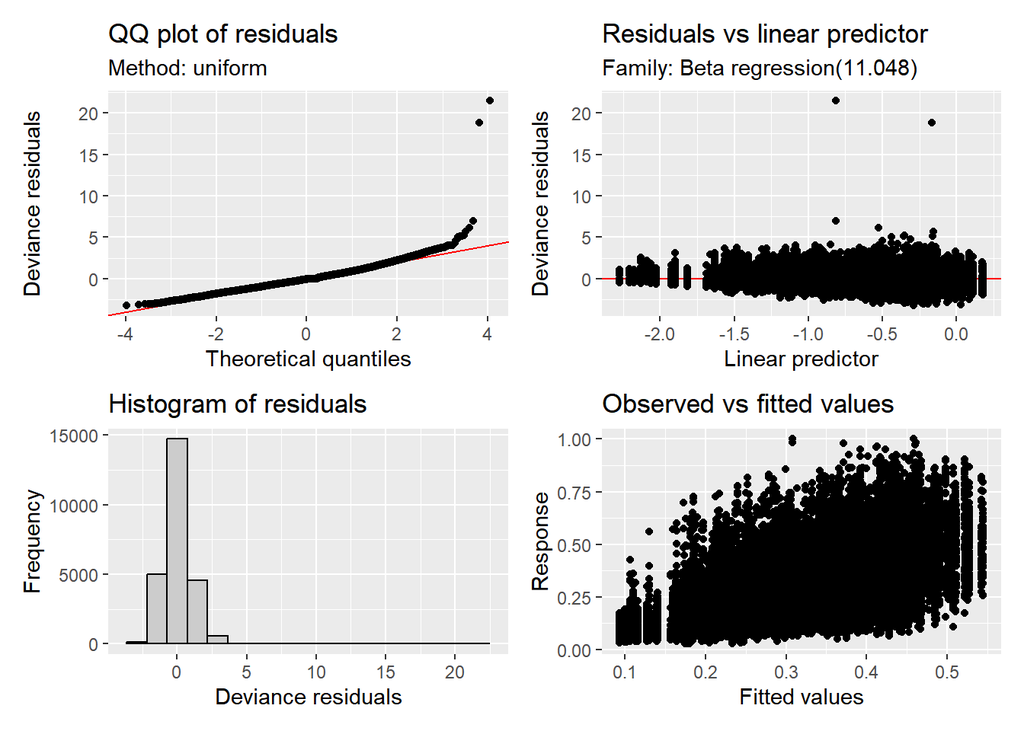

```r
appraise(M1)
```

Все не так плохо!

Вот визуализация модели.

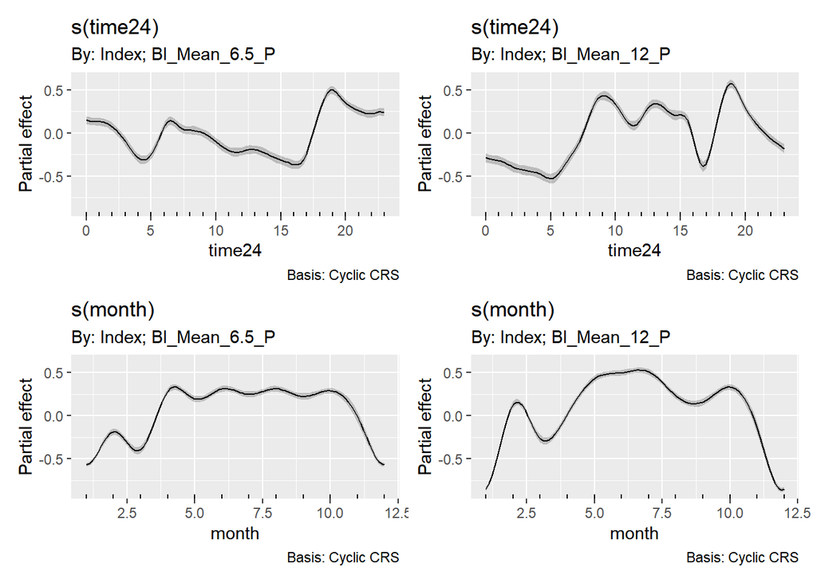

```r
draw(M1, scales = 'fixed')
```

По месяцам тоже есть расхождение, но не столь очевидное. Зато хорошо просматривается зимнее затишье.

Предложения на будущее.

А можно ли индекс BI сделать более дробным, то есть рассмотреть в качестве границ не 6 и 12 кГЦ, а взять несколько пороговых значений? Тогда бы мы могли построить двумерную карту звуковой активности, где по оси ОХ будет идти время, а по оси OY - пороговая частота. На такой карте будут видны “пятна” соответствующие активности разных тварей в разное время (по-моему было бы красиво).